# Prosjekt 3 - Kompakte stjerner

Celle under er for å importere kanselleringslinjer i markdown-koden. Cellene vises ikke riktig i HTML-fil, men vil vises riktig hvis koden kjøres gjennom Jupyter, og markdown-cellene kjøres manuelt i etterkant (Ctrl+Enter). I tillegg ligger en PDF-kopi av notebooken vedlagt med riktig markdown-visning.

```python
%%javascript
MathJax.Extension["TeX/cancel"]={version:"2.4.0",ALLOWED:{color:1,mathcolor:1,background:1,mathbackground:1,padding:1,thickness:1}};MathJax.Hub.Register.StartupHook("TeX Jax Ready",function(){var c=MathJax.InputJax.TeX,a=MathJax.ElementJax.mml,b=MathJax.Extension["TeX/cancel"];b.setAttributes=function(h,e){if(e!==""){e=e.replace(/ /g,"").split(/,/);for(var g=0,d=e.length;g<d;g++){var f=e[g].split(/[:=]/);if(b.ALLOWED[f[0]]){if(f[1]==="true"){f[1]=true}if(f[1]==="false"){f[1]=false}h[f[0]]=f[1]}}}return h};c.Definitions.Add({macros:{cancel:["Cancel",a.NOTATION.UPDIAGONALSTRIKE],bcancel:["Cancel",a.NOTATION.DOWNDIAGONALSTRIKE],xcancel:["Cancel",a.NOTATION.UPDIAGONALSTRIKE+" "+a.NOTATION.DOWNDIAGONALSTRIKE],cancelto:"CancelTo"}},null,true);c.Parse.Augment({Cancel:function(e,g){var d=this.GetBrackets(e,""),f=this.ParseArg(e);var h=b.setAttributes({notation:g},d);this.Push(a.menclose(f).With(h))},CancelTo:function(e,g){var i=this.ParseArg(e),d=this.GetBrackets(e,""),f=this.ParseArg(e);var h=b.setAttributes({notation:a.NOTATION.UPDIAGONALSTRIKE+" "+a.NOTATION.UPDIAGONALARROW},d);i=a.mpadded(i).With({depth:"-.1em",height:"+.1em",voffset:".1em"});this.Push(a.msup(a.menclose(f).With(h),i))}});MathJax.Hub.Startup.signal.Post("TeX cancel Ready")});MathJax.Ajax.loadComplete("[MathJax]/extensions/TeX/cancel.js");
```

### Oppgave 1a)

Vi antar en tilstandsligning for systemet vårt

$$ P \,=\, K \epsilon^{\,\gamma}, \quad \gamma \,=\, 1+\frac{1}{n}, $$

hvor $n$ er *polytropisk indeks*.

Vi innfører de dimensjonsløse variable $\theta$ og $\xi$ slik at

$$ \epsilon\,=\,\epsilon_0 \theta^{\,\left.1\middle/(\gamma-1)\right.}, \quad\, \epsilon_0\,=\,\epsilon(r\,=\,0), $$$$ r\,=\,a\xi,\qquad a\,=\,\left[ \frac{(n+1)Kc^{\,4}\epsilon_0^{\,\gamma-2}}{4\pi G} \right]^{\left. 1 \middle/ 2 \right.}, $$

der $\epsilon_0$ og $a$ er konstanter.

Likning (17) kan da omskrives fra

$$ \frac{1}{r^2} \frac{\mathrm{d}}{\mathrm{d}r} \left( \frac{r^2}{\epsilon}\frac{\mathrm{d}P}{\mathrm{d}r} \right) \,=\, -\frac{4\pi G \epsilon \left(r\right)}{c^4}. $$$$$$

Ved derivasjon av $r$ får vi $\,\mathrm{d}r \,=\, a\mathrm{d}\xi$. Setter inn for $\mathrm{d}r,\,\,r\,=\,a\xi\,$ og $\,P\,=\,K \epsilon^{\,\gamma}\,$, og skriver $\epsilon(r) \,=\, \epsilon\,$ slik at

$$ \frac{1}{(a\xi)^2} \frac{1}{a} \frac{\mathrm{d}}{\mathrm{d}\xi} \left( \frac{(a\xi)^2}{\epsilon}\frac{1}{a} \frac{\mathrm{d}}{\mathrm{d}\xi}\left[K \epsilon^{\,\gamma}\right] \right) \,=\, -\frac{4\pi G \epsilon}{c^4}, $$$$$$

innsatt for $\,\epsilon \,=\, \epsilon_0 \theta^{\,\left.1\middle/(\gamma-1)\right.}\,$ gir

$$ \frac{1}{a^2\xi^2} \frac{1}{a} \frac{\mathrm{d}}{\mathrm{d}\xi} \left( \frac{a^2\xi^2}{\epsilon_0 \theta^{\,1/(\gamma-1)}}\frac{1}{a} \frac{\mathrm{d}}{\mathrm{d}\xi}\left[K \left(\epsilon_0 \theta^{\,\left.1\middle/(\gamma-1)\right.}\right)^{\,\gamma}\right] \right) \,=\, -\frac{4\pi G \epsilon_0 \theta^{\,\left.1\middle/(\gamma-1)\right.}}{c^4}. $$$$$$

Da parameterene $a,\, \epsilon_0,\, \mathrm{og}\, K$ er konstanter, kan disse faktoriseres på tvers av derivasjoner, og dermed kansellere. Ved å faktorisere og kansellere nødvendige faktorer får vi

$$ \frac{K}{a^2\xi^2} \cancel{\frac{1}{a}} \frac{\mathrm{d}}{\mathrm{d}\xi} \left( \frac{\cancel{a^2}\xi^2}{\cancel{\epsilon_0} \theta^{\,\left.1\middle/(\gamma-1)\right.}}\cancel{\frac{1}{a}} \frac{\mathrm{d}}{\mathrm{d}\xi}\left[\left(\cancel{\epsilon_0} \theta^{\,\left.1\middle/(\gamma-1)\right.}\right)^{\,\gamma}\right] \right) \,=\, -\frac{4\pi G \cancelto{\epsilon_0^{\,2-\gamma}}{\epsilon_0} \theta^{\,\left.1\middle/(\gamma-1)\right.}}{c^4}, $$$$$$

som dermed kan forenkles til

$$ \frac{1}{\xi^2} \frac{\mathrm{d}}{\mathrm{d}\xi} \left( \frac{\xi^2}{\theta^{\,\left. 1\middle/(\gamma-1)\right.}} \frac{\mathrm{d}}{\mathrm{d}\xi}\left[\theta^{\,\left. \gamma\middle/(\gamma-1) \right.}\right] \right) \,=\, -\frac{4\pi G \epsilon_0^{\,2-\gamma} a^2}{K c^4} \theta^{\,\left. 1 \middle/(\gamma-1) \right.}. $$$$$$

Innsatt for $a^2$ vil brøken på høyre side forkortes, og vi får

$$ \frac{1}{\xi^2} \frac{\mathrm{d}}{\mathrm{d}\xi} \frac{\xi^2}{\theta^{\,\left. 1\middle/(\gamma-1) \right.}} \underbrace{\frac{\mathrm{d}}{\mathrm{d}\xi}\left[\theta^{\,\left. \gamma \middle/(\gamma-1) \right.}\right]}_{(\mathrm{II})} \,=\, -\frac{\gamma}{\gamma-1} \theta^{\,\left. 1\middle/(\gamma-1) \right.}, $$$$$$

hvor $(\mathrm{II})$ kan omskrives ved kjerneregelen slik at

$$ \frac{\mathrm{d}}{\mathrm{d}\xi}\left[\theta^{\,\left. \gamma \middle/(\gamma-1) \right.}\right] \,=\, \frac{\gamma}{\gamma-1} \theta^{\,\left. \gamma\middle/(\gamma-1) \,-1 \right.} \frac{\mathrm{d}\theta}{\mathrm{d}\xi}, $$

hvor potensen

$$ \frac{\gamma}{\gamma-1} -1 \,=\, \frac{1}{\gamma-1}. $$$$$$

Innsatt i uttrykket får vi da

$$ \frac{1}{\xi^2} \frac{\mathrm{d}}{\mathrm{d}\xi} \frac{\xi^2}{\cancel{\theta^{\,\left. 1\middle/(\gamma-1) \right.}}} \cancel{\frac{\gamma}{\gamma-1}} \cancel{\theta^{\,\left. 1\middle/(\gamma-1) \right.}} \frac{\mathrm{d}\theta}{\mathrm{d}\xi} \,=\, -\cancel{\frac{\gamma}{\gamma-1}} \theta^{\,\left. 1\middle/(\gamma-1) \right.}. $$$$$$

Uttrykket blir da

$$ \frac{1}{\xi^2} \frac{\mathrm{d}}{\mathrm{d}\xi} \xi^2 \frac{\mathrm{d}\theta}{\mathrm{d}\xi} \,=\, -\theta^{\,\left. 1\middle/(\gamma-1) \right.} \tag*{Q.E.D.}, $$

med $n\,=\, \left. 1\middle/ (\gamma-1) \right.$. Denne ligningen vil herved bli referert til som *Lane-Emden ligningen*.

$$$$

Lane-Emden ligningen er en kompakt versjon av de to strukturligningene til stjernen, og brukes med følgende randverdier (likninger 25, 26 i prosjektoppgaven)

$$ \begin{align*} \theta\left(0\right) &\,=\, 1 \\ \theta'\left(0\right) &\,=\, 0 \end{align*} $$

### Oppgave 1b)

Finner løsningen av Lane-Emden ligningen for $n\,=\,0$

$$ \begin{align*} \frac{1}{\xi^2} \frac{\mathrm{d}}{\mathrm{d}\xi} \xi^2 \frac{\mathrm{d}\theta}{\mathrm{d}\xi} &\,=\, -\theta^0 \\ &\,=\,1, \end{align*} $$$$$$

løser for $\xi$

$$ -\xi^2 \,=\, \frac{\mathrm{d}}{\mathrm{d}\xi} \xi^2 \frac{\mathrm{d}\theta}{\mathrm{d}\xi}, $$$$$$

fortsetter å isolere $\xi$ ved å integrere høyre- og venstreside med hensyn på $\xi$

$$ -\int \xi^2 \,\mathrm{d}\xi \, \,=\, \int \frac{\mathrm{d}}{\mathrm{d}\xi} \left[\xi^2 \frac{\mathrm{d}\theta}{\mathrm{d}\xi}\right] \, \mathrm{d}\xi, $$

hvor jeg har innført klammeparantesene på høyre side slik at man tydeligere ser hvilke faktorer derivasjonen virker på. Integrasjonen gir

$$ -\frac{1}{3} \cancelto{\xi}{\xi^{3^\,}} \,=\, \cancel{\xi^2} \frac{\mathrm{d}\theta}{\mathrm{d}\xi}. $$$$$$

Integrerer med hensyn på $\xi$ for å få et uttrykk for $\theta(\xi)$

$$ -\frac{1}{3} \int \xi \, \mathrm{d}\xi \,=\, \int \frac{\mathrm{d}\theta}{\mathrm{d}\xi} \, \mathrm{d}\xi, $$$$$$

løser integralet

$$ \theta(\xi) \,=\, -\frac{1}{6} \xi^2 + C $$

hvor $C$ er en integrasjonskonstant som bestemmes ved randverdiene til Lane-Emden likningen.

$$$$

Løsningen av Lane-Emden ligningen for $n\,=\,0$ blir dermed

$$ \theta(\xi) \,=\, -\frac{1}{6} \xi^2 + 1 $$

### Oppgave 1c)

Finner løsningen av Lane-Emden ligningen for $n\,=\,1 \Leftrightarrow \gamma\,=\,2$

$$ \frac{1}{\xi^2} \frac{\mathrm{d}}{\mathrm{d}\xi} \xi^2 \frac{\mathrm{d}\theta}{\mathrm{d}\xi} \,=\, -\theta, $$$$$$

setter inn for $\theta \,=\, \frac{u}{\xi} \Rightarrow \frac{\mathrm{d}\theta}{\mathrm{d}\xi} \,=\, \frac{\mathrm{d}}{\mathrm{d}\xi} \left[ \frac{u}{\xi} \right]$, og løser for $\xi$

$$ -\frac{u}{\cancel{\xi}} \cancelto{\xi}{\xi^{2^\,}} \,=\, \frac{\mathrm{d}}{\mathrm{d}\xi} \bigg[ \cancel{\xi^{2^\,}} \underbrace{\frac{\mathrm{d}}{\mathrm{d}\xi} \left[ \frac{u}{\xi} \right]}_{\left. (u'\xi-u) \middle/ \cancel{\xi^2} \right.} \bigg], $$

hvor jeg igjen har innført klammeparantesene på høyre side slik at man tydeligere ser hvilke faktorer derivasjonen virker på. Uttrykket forenkles til

$$ \frac{\mathrm{d}}{\mathrm{d}\xi} \left[ \frac{\mathrm{d}u}{\mathrm{d}\xi}\xi-u \right]\,=\,-u\xi. \\ $$

Med kjerneregel gir derivasjon av venstresiden følgende uttrykk

$$ \frac{\mathrm{d}^2u}{\mathrm{d}\xi^2} \cancel{\xi} \,=\, -u\cancel{\xi}. \\ $$

Løser ODE'en ved å anta en løsning $u\,=\,e^{\alpha \xi}$ for en vilkårlig $\alpha$

$$ e^{\alpha \xi} \left(\alpha^2 +1 \right) \,=\, 0 \quad \Rightarrow \quad \alpha \,=\, i. \\ $$

Vi får da at løsningen for $u$ blir

$$ u \,=\, ae^{i \xi} \equiv A\sin(\xi) + B\cos(\xi), \\ $$

hvor siste ledd er en direkte konsekvens av å bruke Eulers sammenheng mellom naturlige eksponenser og trigonometriske uttrykk. Uttrykket for $\theta$ blir

$$ \theta \,=\, A\frac{\sin(\xi)}{\xi} + B\frac{\cos(\xi)}{\xi}, $$

med randverdien $\theta(0)\,=\,1$ ser vi på følgende grenser

$$ \begin{align*} &\lim_{\xi \rightarrow 0} \,\, B\frac{\cos(\xi)}{\xi} \,=\, 0 & \therefore B\,=\,0, \\ \\ &\lim_{\xi \rightarrow 0} \,\, A\frac{\sin(\xi)}{\xi} \,=\, 1 & \therefore A\,=\,1. \\ \\ \end{align*} $$

Vi får dermed at uttrykkene for henholdsvis $u \mathrm{\, og \,} \theta$ blir

$$ \begin{align*} u(\xi) &\,=\,\sin(\xi) \\ \\ \theta(\xi) &\,=\, \frac{\sin(\xi)}{\xi}. \\ \end{align*} $$

### Oppgave 2a)

Bruker at $M=M(r)$, slik at

$$ \frac{2GM}{c^2}=\frac{2GM(r)}{c^2}\\ \Rightarrow r_s = \frac{2GM}{c^2} \frac{r^3}{R^3} $$

Kjerneregelen gir at

$$ \frac{\partial \bar{P}}{\partial x}=\frac{\partial \bar{P}}{\partial r} \frac{\partial r}{\partial x}=\frac{1}{\rho_0 c^2} \frac{\partial P}{\partial r} \frac{\partial r}{\partial x}=\frac{1}{\varepsilon} \left(-\frac{G\varepsilon m(r)}{c^2 r^2}\left[1+\bar{P}\right]\left[1+\frac{4\pi r^3 P(r)}{m(r)c^2}\right]\left[1-\frac{2Gm(r)}{c^2 r}\right]^{-1} \right)\cdot R $$$$ \\ = \frac{-GMR}{c^2 r^2} \left[1+\bar{P}\right]\left[1+3\bar{P}\right] \left[1-\frac{2GM}{c^2r}\right]^{-1} \\ $$

De to første parentesuttrykkene stemmer overens med det vi skal vise. Har da igjen $$ \frac{-GMR}{c^2 r^2} \left[1-\frac{2GM}{c^2r}\right]^{-1} = -\frac12 \frac{r_s R}{r^2} \frac{r^3}{R^3} \left[1- \frac{r_s}{r} \frac{r^3}{R^3}\right]^{-1} $$ $$ =-\frac12 \frac{r_s r}{R^2} \left[ \frac{R^3-r_s r^2}{R^3}\right]^{-1}=-\frac12 \frac{r_s r}{1}\left[\frac{R^1}{R^3-r_s r^2}\right] \\\\ =-\frac12 \frac{r_s r R}{R^3-r_sr^2}=-\frac12 \frac{\alpha x R^3}{R^3-\alpha x^2 R^3} $$

$$ =-\frac12 \frac{\alpha x}{1-\alpha x^2} $$$$ \therefore \frac{\partial \bar{P}}{\partial x}=-\frac12 \alpha x [1+\bar{P}][1+3\bar{P}][1-x^2\alpha]^{-1} \tag*{■} $$

### Oppgave 2b)

Sepererer variablene og får $$ \frac{\partial \bar{P}}{(1+\bar{P})(1+3\bar{P})}=\frac{-0.5\alpha x}{1-x^2\alpha}\partial x $$

Høyre side er et standard integral og blir $\frac14 \ln{(1-\alpha x^2)}+C$

På venstre side brukes delbrøksoppspaltning for å evaluere

$$ \frac{1}{(1+\bar{P})(1+3\bar{P})}=\frac{A}{1+\bar{P}}+\frac{B}{1+3\bar{P}} $$$$ \Rightarrow A+B=1 \wedge 3A+B=0\\ $$$$ \Rightarrow B=-3A \Leftrightarrow -2A=1 \Leftrightarrow A = -1/2 \Rightarrow B=3/2 $$$$ \int{\frac{-1/2}{1+\bar{P}}+\frac{3/2}{1+3\bar{P}}}\mathrm{d \bar{P}}=\int{\frac{-0.5 \alpha x}{1-x^2\alpha}} \mathrm{dx} $$$$ \Rightarrow -\ln{(1+\bar{P})}+\ln{(1+3\bar{P})}=\frac12 \ln{(1-\alpha x^2)}+C_1 $$

I steget over har er det multiplisert med to overalt for å forenkle utregningen. Løser herfra uttrykk for $\bar{P}(x)$ og får

$$ \frac{1+3\bar{P}}{1+\bar{P}}=(1-\alpha x^2)^{1/2}\cdot C_2 \\ \Rightarrow 3\bar{P}-\bar{P}\cdot C_2 \sqrt{1-\alpha x^2}=C_2 \sqrt{1-\alpha x^2}-1 \\ \Rightarrow \bar{P}=\frac{C_2 \sqrt{1-\alpha x^2}-1}{3-C_2 \sqrt{1-\alpha x^2}} $$

Har randbetingelsen $\bar{P}(1)=0$, dette gir verdien $$C_2=\frac{1}{\sqrt{1-\alpha}},$$

og endelig uttrykk blir

$$ \bar{P}(x)=\frac{\sqrt{\frac{1-\alpha x^2}{1-\alpha}}-1}{3-\sqrt{\frac{1-\alpha x^2}{1-\alpha}}}=\frac{\sqrt{1-\alpha}-\sqrt{1-\alpha x^2}}{\sqrt{1-\alpha x^2}-3\sqrt{1-\alpha}}, \tag*{■} $$

### Oppgave 2c)

Vi ser på (37) som $$\bar{P}(\alpha)=\frac{\sqrt{1-\alpha}-\sqrt{1-\alpha x^2}}{\sqrt{1-\alpha x^2}-3\sqrt{1-\alpha}}$$

For små nok $\alpha$, skal det holde å approksimere $$\bar{P}(\alpha)\approx P(\alpha=0)+\frac{\partial \bar{P}(\alpha=0)}{\partial \alpha}\cdot \alpha$$

Ved innsetting ser man at $\bar{P}(\alpha=0)=0$. Finner førstederiverte:

$$ \frac{\partial \bar{P}}{\partial \alpha} = \frac{\left[\sqrt{1-\alpha}-\sqrt{1-\alpha x^2}\right]'\cdot (\sqrt{1-\alpha x^2}-3\sqrt{1-\alpha})-\left[\sqrt{1-\alpha x^2}-3\sqrt{1-\alpha}\right]'\cdot (\sqrt{1-\alpha}-\sqrt{1-\alpha x^2})}{\left(\sqrt{1-\alpha x^2}-3\sqrt{1-\alpha}\right)^2}, \\ \\ $$

der $\left[\sqrt{1-\alpha}-\sqrt{1-\alpha x^2}\right]'=\frac{-1}{2\sqrt{1-\alpha}}+\frac{x^2}{2\sqrt{1-\alpha x^2}} $ og $\left[\sqrt{1-\alpha x^2}-3\sqrt{1-\alpha}\right]'=\frac{-x^2}{2\sqrt{1-\alpha x^2}}+\frac{3}{2\sqrt{1-\alpha}}$

som, evaulert om $\alpha=0$, blir $$ \frac{\partial \bar{P}(\alpha=0)}{\partial \alpha}= \frac{[-\frac12+\frac{x^2}{2}](1-3)-[1-1](\frac{-x^2}{2}+\frac32)}{(1-3)^2}=\frac14 (1-x^2) $$

$$ \Rightarrow \bar{P}(\alpha)\approx 0+\frac14 (1-x^2) \cdot \alpha=\frac14 \alpha(1-x^2) \tag*{■} $$

### Oppgave 3a)

Ved hjelp av Taylors teorem kan den eksakte løsningen, $y(x_{0} + h)$, skrives om til en form gitt ved

$$ y(x_{0} + h) = y(x_{0}) + hy'(x_{0}) + \frac{1}{2!}h^{2}y''(\tau), $$

slik at

$$ \tau_{1} = y(x_{0}) + hy'(x_{0}) + \frac{1}{2!}h^{2}y''(\tau) - y(x_{0}) - hy'(x_{0}) = \frac{1}{2!}h^{2}y''(\tau), $$

der $\tau \in [\tau_{0},\tau_{0} + h]$.

Altså er $\tau_{1}$ proporsjonal med $h^{2}$.

### Oppgave 3b)

Den globale feilen for Eulers metode er akkumulasjonen av feilen gjort i hvert tidssteg og er gitt ved

$$ E_{N} = |y(t_{N}) - y_{t_{N}}|. $$

Vi vet allerede at den lokale feilen er av orden $\mathcal{O}h^{2}$, altså vil man for hvert tidssteg få feilen $kh^{2}$, hvor k er en konstant. For å nå approksimasjonen av differensiallikningen gitt ved verdien $x_{N}$ benytter man $N$ steg. Sammenhengen mellom $N$ og $h$ er gitt ved

$$ N = \frac{x_{N} - x_{0}}{h}, $$

som viser at antall skritt er invers proporsjonal med h. Dermed blir den globale feilen

$$ E_{N} = kh^{2}\frac{1}{h} = kh. $$

Altså er Eulers metode av orden $\mathcal{O}h$.

### Oppgave 3c)

Lane-Emden ligningen er gitt ved

$$ \frac{1}{\xi^{2}}\frac{\mathrm{d}}{\mathrm{d}\xi}(\xi^{2}\frac{\mathrm{d}\theta}{\mathrm{d}\xi}) = -\theta^{n} $$

For å redusere Lane-Emden ligningen til et system av to førsteordens differensialligninger forenkles først denne til å bli

$$ \frac{1}{\xi^{2}}(2\xi\frac{\mathrm{d}\theta}{\mathrm{d}\xi}+\xi^{2}\frac{\mathrm{d^{2}}\theta}{\mathrm{d}\xi^{2}}) = \theta''+\frac{2}{\xi}\theta' = -\theta^{n}. $$

Videre innføres $u = \theta$ og $v = \theta'$ slik at $u' = \theta' = v$ og $v' = \theta'' = -\frac{2}{\xi}v-\theta^{n}$. Dermed kan Lane_emden ligningen skrives som en vektorligning hvor

$$ \begin{bmatrix} u'\\ v'\\ \end{bmatrix} = \begin{bmatrix} v\\ -\frac{2}{\xi}v-u^{n}\\ \end{bmatrix} $$

Ved å innføre $x = \theta'$ kan dette skrives som

$$ \begin{bmatrix} g_{1}(x)\\ g_{2}(\theta,x,\xi)\\ \end{bmatrix} = \begin{bmatrix} x\\ -\frac{2}{\xi}x-\theta^{n}\\ \end{bmatrix} $$

### Oppgave 3d)

Ved å benytte Eulers metode på $g_{1}$ og $g_{2}$, for n = 1 får man

$$ y_{n+1} = y_{n} + hx_{n} $$$$ x_{n+1} = x_{n} + h(-\frac{2}{\xi}x-\theta_{n}) $$

```python
# IMPORTS
import numpy as np
import matplotlib.pyplot as plt
import warnings
warnings.filterwarnings('ignore')
########

def solve_numeric(numeric_method, h, f, m, init_cond, x0=0, xend=1, implicit_N=False):
        """ Numerisk løsningsalgoritme for både Euler og RK4.
            Også utformet med utgangspunkt i utdelt kode på NUMFYS.
        Parametere:
                h:          Steglende
                f:          Høyreside av  ODE (vektorfunksjon)
                m:          Polytropisk indeks for Lane-Embden og alpha for P(x)
                init_cond:  Numpyarray som inneholder initalbetingelsene
                            For Lane-Embden blir dette [1,0]
                x0:         x-verdi (eller xi) for initialbetingelsen
                xend:       Slutten på intervallet der Euler-metoden utføres
                explicit_N: Bool-verdi som justerer antall steg, slik at samme funksjon kan brukes
        Returverdier:
                M:          Matrise med antall rader = orden til ODE (Lane-Embden: 2), og N kolonner
                            Inneholder numerisk approksimasjon av y/theta ved tidspunktene x_list
                t_list:     Liste av ekvidistante x/xi-verdier med mellomrom h, fra [x0, xend]"""
        deg = len(init_cond) # The order of the ODE is equal to the number of initial conditions we need
        if implicit_N:
            global N #Using number of steps defined outside function scope, used in task 3g
        else:
            N = int((xend - x0) / h) #Number of steps
        x_list = np.linspace(x0, xend, N + 1)
        M = np.zeros((deg, N + 1)) # Matrix storing the values of the variable we wish to solve for
        # (the zeroth derivative), as well as the higher order derivatives
        M[:, 0] = init_cond # Storing the initial conditions
        for i in range(0, N):
            M[:,i + 1] = numeric_method(M[:, i], x_list[i], h, f, deg, m) # Running N Euler steps
        return M, x_list
```

```python
def step_Euler_high(w, x, h, f, deg, m):
    """Implementasjon av Eulers metode. Koden er utformet med utgangspunkt på utdelt kode,
    hentet fra NUMFYS: https://nbviewer.jupyter.org/urls/www.numfys.net/media/notebooks/Eulers_method_-_updated_module_-_Done_1.ipynb
    Performs a single step of Euler's method on vector form.

    Parameters:
            w: Numerical approximation of w at time t
            t: The time the Euler step is preformed at
            h: Step size
            f: RHS of our ODE
            m: polytropic index
        Returns:
            next_w: Numerical approximation of x at time t+h
    """
    next_w = w + h * f(w, x, deg, m)
    return next_w

def g(w, x, deg, m):
    """Defines the right hand side of our differential equation. In our case it is a vector function that
    determines the equation of motion.
        Parameters:
                w: Numerical approximation of w at time t
                t: Time, not relevant here as we have no explicit time dependence
                deg: Degree of the ODE we wish to solve
            Returns:
                next_w: Numerical approximation of w at time t
        """
    next_w = np.zeros(deg)
    next_w[0] = w[1]
    if x ==0: #Dette kom vi fram til i samsvar med foreleser, benyttes i oppg. 3g
        next_w[1] = -1/3
    else:
        next_w[1] = -2/x * w[1] - np.absolute(w[0])**(m)
    return next_w
```

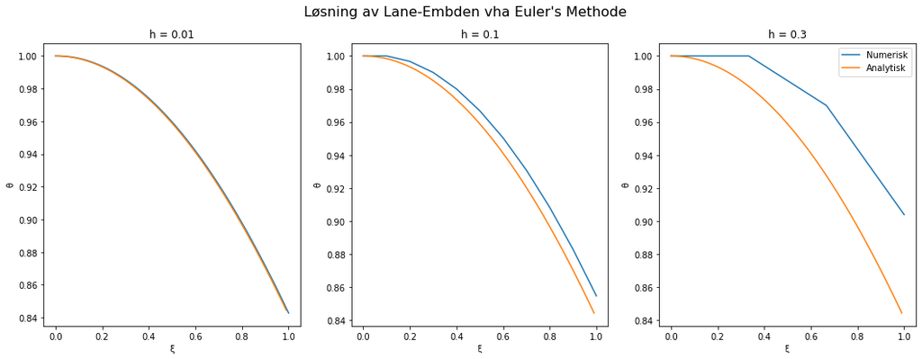

```python
steplengths = [0.01, 0.1, 0.3]
xx = np.arange(0.00001,1,0.01) #For å plotte analytisk løsning
fig, ax = plt.subplots(1,3, figsize=(18, 6))
fig.suptitle("Løsning av Lane-Embden vha Euler's Methode", fontsize=16)
for i, h in enumerate(steplengths): #Itererer gjennom gitte steglengder
    M, xi = solve_numeric(step_Euler_high, h, g, 1, np.array([1,0]), 0, 1) #Beregner numerisk løsning
    ax[i].set_title("h = " + str(h))
    ax[i].set_xlabel("\u03BE")
    ax[i].set_ylabel("\u03B8")
    ax[i].plot(xi, M[0], label ="Numerisk")
    ax[i].plot(xx,np.sin(xx)/xx, label="Analytisk")
plt.subplots_adjust(hspace=1.5)
plt.legend()
plt.show()
```

### Oppgve 3e)

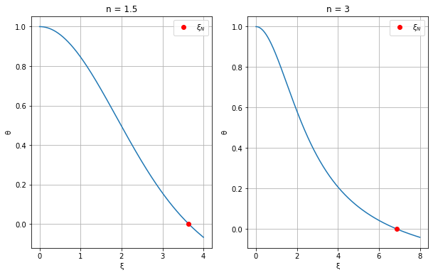

```python
polytropic_indices = [3/2, 3]
fig, ax = plt.subplots(1,2, figsize=(10, 6))
for i, n in enumerate(polytropic_indices):
    #Beregner numerisk løsning for hver n. Første plott går fra [0,4], andre fra  [0,8]
    M, xi = solve_numeric(step_Euler_high, 0.01, g, n, np.array([1,0]), 0, 4*(i+1))
    ax[i].set_title("n = " + str(n))
    ax[i].set_xlabel("\u03BE")
    ax[i].set_ylabel("\u03B8")
    ax[i].plot(xi, M[0]) #Plotting theta(xi)
    ax[i].grid()
    idx = np.argwhere(np.diff(np.sign(M[0]-0))).flatten() #Finner skjæringspunkt
    ax[i].plot(xi[idx][0], M[0][idx][0], 'ro', label=r'$\xi_N$')
    ax[i].legend()
plt.show()
```

### Oppgave 3f)

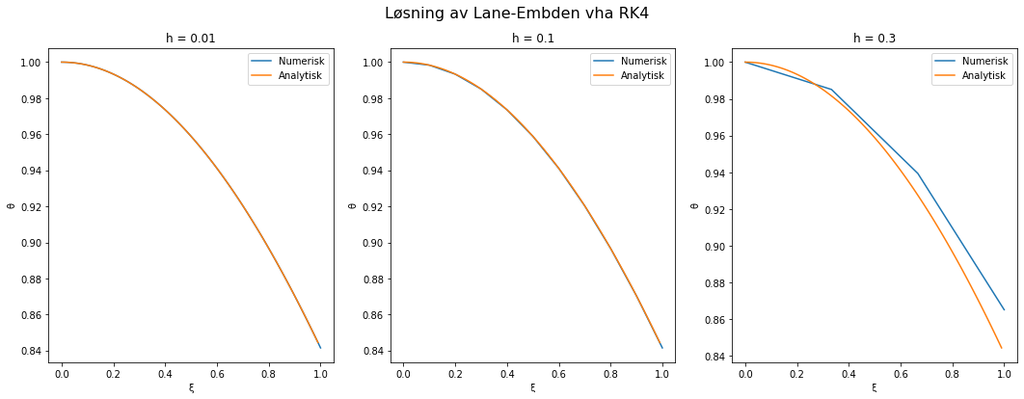

```python
def RK4_step(w, x, h, f, deg, m):
    """ Ett steg ved fjerdeordens Runge-Kutta"""
    k1 = f(w, x, deg, m)
    k2 = f(w+h*k1/2, x+h/2, deg, m)
    k3 = f(w+h*k2/2, x+h/2, deg, m)
    k4 = f(w+h*k3, x+h, deg, m)
    return w + h/6*(k1+2*k2+2*k3+k4)

RK_steplen = [0.01, 0.1, 0.3]
fig, ax = plt.subplots(1,3, figsize=(18,6))
fig.suptitle("Løsning av Lane-Embden vha RK4", fontsize=16)
for i, h in enumerate(RK_steplen):
    M, xi = solve_numeric(RK4_step, h, g, 1, np.array([1,0]), 0, 1)
#   Parametere:   (numeric_method,  h, f, m,    init_cond,    x0,   xend)
    ax[i].set_title("h = " + str(h))
    ax[i].set_xlabel("\u03BE")
    ax[i].set_ylabel("\u03B8")
    ax[i].plot(xi, M[0], label="Numerisk")
    ax[i].plot(xx, np.sin(xx)/xx, label="Analytisk")
    ax[i].legend()
plt.show()
```

### Oppgave 3g)

Bruker oppgitte verdier etter faglærers anbefaling for $\xi_N$, både for det ultra- og ikke-relativistiske tilfellet, da disse er mer nøyaktige. Bruker disse verdiene:

$$ \begin{align} & \xi_{\mathrm{ikke \, relativistisk}} = 3.653753736219229 \\ & \xi_{\mathrm{ultra \, relativistisk}} = 6.89684861937 \end{align} $$

```python
xi_N_rel = 6.89684861937  #n=3
xi_N_irel = 3.653753736219229 #n=3/2
ic = np.array([1,0]) #initial condition

n_rel = 3
n_irel = 3/2
 #Skal være 800
N_arr = np.array([1 + 2*i for i in range(800)]) #steglengde fra 0.0985 til 0.00835
h_arr_rel = xi_N_rel/N_arr
h_arr_irel = xi_N_irel/N_arr
eRK4_rel = np.zeros(len(N_arr))
eRK4_irel = np.zeros(len(N_arr))
eEuler_rel = np.zeros(len(N_arr))
eEuler_irel = np.zeros(len(N_arr))

#def solve_numeric(numeric_method, h, f, m, init_cond, x0=0, xend=1, explicit_N=False):
#RK4_step ELLER step_Euler_high

for i, N in enumerate(N_arr):
    #Ultrarelativistisk, RK4
    MRK4_rel, xiRK4_rel = solve_numeric(RK4_step, h_arr_rel[i], g, n_rel, ic, 0, xi_N_rel, True)
    thetaRK4_rel = MRK4_rel[:][0][-1]
    eRK4_rel[i] = np.absolute(thetaRK4_rel)
    #Ikke-relativtistisk, RK4
    MRK4_irel, xiRK4_irel = solve_numeric(RK4_step, h_arr_irel[i], g, n_irel, ic, 0, xi_N_irel, True)
    thetaRK4_irel = MRK4_irel[:][0][-1]
    eRK4_irel[i] = np.absolute(thetaRK4_irel)
    #Ultrarelativtistisk, Euler
    MEuler_rel, xiEuler_rel = solve_numeric(step_Euler_high, h_arr_rel[i], g, n_rel, ic, 0, xi_N_rel, True)
    thetaEuler_rel = MEuler_rel[:][0][-1]
    eEuler_rel[i] = np.absolute(thetaEuler_rel)
    #Ikke-relativistisk, Euler
    MEuler_irel, xiEuler_irel = solve_numeric(step_Euler_high, h_arr_irel[i], g, n_irel, ic, 0, xi_N_irel, True)
    thetaEuler_irel = MEuler_irel[:][0][-1]
    eEuler_irel[i] = np.absolute(thetaEuler_irel)
```

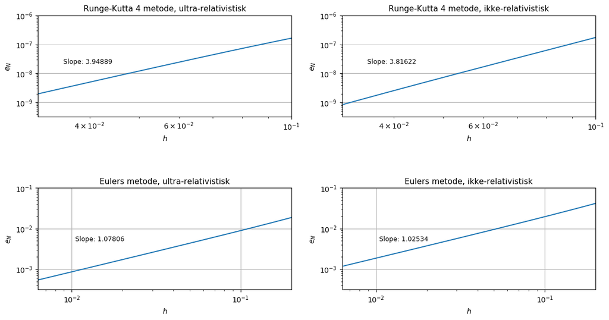

```python
plt.figure("", figsize=(10, 7), dpi=(100), )

'''RK4, ultra-relativistisk'''
axRK4_rel = plt.subplot(221)
axRK4_rel.set_title("Runge-Kutta 4 metode, ultra-relativistisk", fontsize=11)
axRK4_rel.loglog(h_arr_rel, eRK4_rel)
slope_RK4_rel, intercept_RK4_rel = np.polyfit(np.log(h_arr_rel), np.log(eRK4_rel), 1)
axRK4_rel.text(10**(-1.45), 10**(-7.65), "Slope: {}".format(round(slope_RK4_rel, 5)), fontsize = 9)
axRK4_rel.grid()
axRK4_rel.set_xlabel("$h$")
axRK4_rel.set_ylabel(r"$e_N$")

axRK4_rel.set_ylim(10**(-9.5), 1e-6)
axRK4_rel.set_xlim(10**(-1.5), 1e-1)
#------------------

'''RK4, ikke-relativistisk'''
axRK4_irel = plt.subplot(222)
axRK4_irel.set_title("Runge-Kutta 4 metode, ikke-relativistisk", fontsize = 11)
axRK4_irel.loglog(h_arr_irel, eRK4_irel)
slope_RK4_irel, intercept_RK4_irel = np.polyfit(np.log(h_arr_irel), np.log(eRK4_irel), 1)
axRK4_irel.text(10**(-1.45), 10**(-7.65), "Slope: {}".format(round(slope_RK4_irel, 5)), fontsize = 9)
axRK4_irel.grid()
axRK4_irel.set_xlabel("$h$")
axRK4_irel.set_ylabel(r"$e_N$")

axRK4_irel.set_ylim(10**(-9.5), 1e-6)
axRK4_irel.set_xlim(10**(-1.5), 1e-1)
#------------------

'''Euler, ultra-relativistisk'''
axEuler_rel = plt.subplot(223)
axEuler_rel.set_title("Eulers metode, ultra-relativistisk", fontsize=11)
axEuler_rel.loglog(h_arr_rel, eEuler_rel)
slope_Euler_rel, intercept_Euler_rel = np.polyfit(np.log(h_arr_rel), np.log(eEuler_rel), 1)
axEuler_rel.text(10**(-1.98), 10**(-2.3), "Slope: {}".format(round(slope_Euler_rel, 5)), fontsize = 9)
axEuler_rel.grid()
axEuler_rel.set_xlabel("$h$")

axEuler_rel.set_ylabel(r"$e_N$")
axEuler_rel.set_ylim(10**(-3.5), 1e-1)
axEuler_rel.set_xlim(10**(-2.2), 10**(-0.7))
#------------------

'''Euler, ikke-relativistisk'''
axEuler_irel = plt.subplot(224)
axEuler_irel.set_title("Eulers metode, ikke-relativistisk", fontsize=11)
axEuler_irel.loglog(h_arr_irel, eEuler_irel)
slope_Euler_irel, intercept_Euler_irel = np.polyfit(np.log(h_arr_irel), np.log(eEuler_irel), 1)
axEuler_irel.text(10**(-1.98), 10**(-2.3), "Slope: {}".format(round(slope_Euler_irel, 5)), fontsize = 9)
axEuler_irel.grid()
axEuler_irel.set_xlabel("$h$")
axEuler_irel.set_ylabel(r"$e_N$")

axEuler_irel.set_ylim(10**(-3.5), 1e-1)
axEuler_irel.set_xlim(10**(-2.2), 10**(-0.7))
#------------------

plt.subplots_adjust(right=1.2, hspace=0.7)
plt.show()
```

I grafene som viser et loglog-plot av globalfeil for Eulers metode i de to tilfellene ser man at stigningstallet ligger på tilnærmet $1$, noe som stemmer overens med en kompleksitet på $\mathcal{O}(h)$ som vist i oppgave 3b).

Ved å benytte antall steg satt til 1500 istedet for 800 fikk vi et stigningstall for RK4 på $3.60051$ og $3.67417$ for henholdsvis ultra-relativistisk og ikke-relatitistisk tilfelle. For Euler hadde ikke endringen i antall steg en like stor effekt men man så også der at stigningstallet ble litt mindre. Denne minskningen i stigningstall, særlig for RK4 tyder på at feilen flater ut for veldig små $h$. Dette kommer av at man får mindre usikkerhet, altså avvik fra eksakt verdi ved bruk av mindre steglengde, som henger sammen med antall steg. Grafen flater altså ut da feilen aldri kan bli mindre enn $0$.

### Oppgave 3h)

Ligning (36) fra prosjektoppgaven er den dimensjonsløse likningen

$$ \frac{\mathrm{d}\bar{P}}{\mathrm{d}x}(x) \,=\, -\frac{1}{2}\alpha x\left[1+\bar{P}\right]\left[1+3\bar{P}\right]\left[1-x^2\alpha\right]^{-1} \tag*{(36)}\\ $$

som er løst analytisk til følgende linking

$$ \bar{P}(x) \,=\, \frac{\sqrt{1-\alpha}-\sqrt{1-\alpha x^2}}{\sqrt{1-\alpha x^2}-3\sqrt{1-\alpha}}. \tag*{(37)}\\ \\ $$

Finner henholdsvis randverdien $\bar{P}(x\,=\,0)$ og $\left. \frac{\mathrm{d}\bar{P}}{\mathrm{d}x} \right|_{x\,=\,0} \\ $

$$ \begin{align*} \bar{P}(x\,=\,0) &\,=\, \left. \frac{\sqrt{1-\alpha}-\sqrt{1-\alpha x^2}}{\sqrt{1-\alpha x^2}-3\sqrt{1-\alpha}} \right|_{x\,=\,0} \\ \\ &\,=\,\frac{\sqrt{1-\alpha}-\sqrt{1}}{\sqrt{1}-3\sqrt{1-\alpha}} \tag*{■} \\ \\ \frac{\mathrm{d}\bar{P}}{\mathrm{d}x} \left(x\,=\,0\right) &\,=\, \left. -\frac{1}{2}\alpha x\left[1+\bar{P}\right]\left[1+3\bar{P}\right]\left[1-x^2\alpha\right]^{-1} \right|_{x\,=\,0} \\ &\,=\, 0 \tag*{■} \end{align*} $$

### Oppgave 3i)

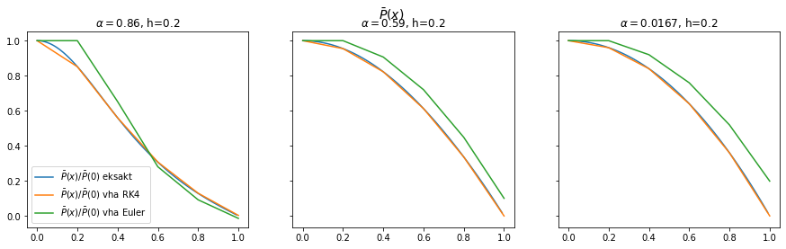

```python
alphas = [0.86, 0.59, 0.0167]
step_length = 0.2

P0 = lambda a : (np.sqrt(1-a)-1)/(1-3*np.sqrt(1-a)) #(57)
dpdx = lambda y, x, deg, a : -0.5*a*x*(1+y)*(1+3*y)*(1-x*x*a)**(-1) #(36)
exact_P = lambda x, a : (np.sqrt(1-a)-np.sqrt(1-a*x*x))/(np.sqrt(1-a*x*x)-3*np.sqrt(1-a)) #(37)

fig, ax = plt.subplots(1,3, sharex=True, sharey=True)
fig.suptitle(r'$\bar{P}(x)$', fontsize=14)
fig.set_figwidth(15)
ls_x = np.arange(0.0001, 1, 0.01) #Linspace for å plotte analytisk likning
for i, a in enumerate(alphas):
    init_cond_3i = np.array([P0(a)])
    RK4_M, RK4_xi = solve_numeric(RK4_step, step_length, dpdx, a, init_cond_3i, 0, 1)
    euler_M, euler_xi = solve_numeric(step_Euler_high, step_length, dpdx, a, init_cond_3i, 0, 1)
    ax[i].set_title(r'$\alpha=$' + str(a) + ", h=" + str(step_length))
    ax[i].plot(ls_x, exact_P(ls_x, a)/P0(a), label=r'$\bar{P}(x)/\bar{P}(0)$ eksakt')
    ax[i].plot(RK4_xi, RK4_M[0]/P0(a), label=r'$\bar{P}(x)/\bar{P}(0)$ vha RK4')
    ax[i].plot(euler_xi, euler_M[0]/P0(a), label=r'$\bar{P}(x)/\bar{P}(0)$ vha Euler')
    if i==0: ax[i].legend(loc=3)
#plt.subplots_adjust(top=1)
fig.tight_layout(rect=[0, 0, 0, 0.9])
plt.show()
```

**Valg av steglengde** For oppgave 3i og 3j har vi valgt steglengde $h=0.2$. Hensikten med oppgaven er å vise frem hvordan de numeriske løsningene for hhv Eulers metode og Runge Kuttas metode avviker fra den eksakte løsningen. Det er derfor hensiktsmessig med en relativt høy steglengde, slik at de numeriske løsningene ikke ser identiske ut. For $h<0.2$ kunne man heller ikke se forskjell på eksakt løsning og løsning vha RK4, noe som ikke er ideelt for denne oppgaven.

### Oppgave 3j)

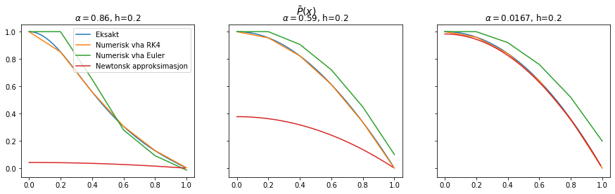

```python
def NewtonApprox(a,x):
    return 1/4*a*(1-x**2)

################   Plotting  ##############
#Plotter på tilsvarende måte som i 3i, legger bare til newtonske plott i hvert subplot
fig, ax = plt.subplots(1,3, sharex=True, sharey=True)
fig.suptitle(r'$\bar{P}(x)$', fontsize=14)
fig.set_figwidth(15)
ls_x = np.arange(0.0001, 1, 0.01) #Linspace for å plotte analytisk og newtonsk graf
for i, a in enumerate(alphas):
    init_cond_3i = np.array([P0(a)])
    RK4_M, RK4_xi = solve_numeric(RK4_step, step_length, dpdx, a, init_cond_3i, 0, 1)
    euler_M, euler_xi = solve_numeric(step_Euler_high, step_length, dpdx, a, init_cond_3i, 0, 1)
    ax[i].set_title(r'$\alpha=$' + str(a) + ", h=" + str(step_length))
    ax[i].plot(ls_x, exact_P(ls_x, a)/P0(a), label=r'Eksakt')
    ax[i].plot(RK4_xi, RK4_M[0]/P0(a), label=r'Numerisk vha RK4')
    ax[i].plot(euler_xi, euler_M[0]/P0(a), label=r'Numerisk vha Euler')
    ax[i].plot(ls_x, NewtonApprox(a,ls_x)/P0(a), label=r'Newtonsk approksimasjon')
    if i==0: ax[i].legend()
plt.subplots_adjust(hspace=0.5)
plt.show()
```

Ser fra grafene at Newton approksimasjonen er god for små $\alpha$, dette fordi den Newtonske approksimasjonen, ligning (43) i oppgaveheftet, ble utledet ved å anta en liten $\alpha$.